# A3: SPL Library Checkouts

### Introduction

The data we are analyzing for this project comes from the Seattle Public Library database of media checkouts. The data set that is being used describes the media entities that were checked out at least 10 times a month between 2017 and 2023. There are 12 columns, ranging from the type of media (Physical/Digital) to the unique ISBN and author/titles. This data set has greater than 800,00 rows, or individual entries. I think it would be beneficial to analyze the frequency of physical/digital checkouts over time. Because this data set records before the COVID-19 pandemic, my hypothesis is that physical checkouts decreased drastically around 2019/2020, and an inverse relationship occurred with digital media. This information could tell us more about media consumption during the pandemic and how the library might be able to expand it’s options to be of more service to the public.

### Summary Information

After some initial analysis of the data set, some interesting general insights can be gained. From this 816,354 entry set, we found that the average checkout of an item was 192.53. It is important to consider that this data set spans from January 2017 - February 2023. As for a single title statistic, the novel “Anna Karenina” was checked out the most in May of 2022. September 2022 saw the most checkouts of ebooks in a single month. One insight that was of importance was the number of print book checkouts over time.

| CheckoutYear | Checkouts |
| --- | --- |
| 2017 | 1447823 |
| 2018 | 1527112 |
| 2019 | 1490783 |
| 2020 | 363157 |
| 2021 | 639460 |
| 2022 | 844552 |

It was interesting to see woe the number of print checkouts dropped between 2019 and 2020. There also seems to be an increase from 2020 to 2022 (suggesting that people are checking out print books once again). One last insightful statistic is the ratio of book checkouts to ebook checkouts, which is 1.266.

### The Dataset

- Who collected/published the data?  
  The Seattle Open Data department facilitates the organization and publication of many different datasets pertaining to utilities and services around the city. This data set in partical is compiled from data collected by the Seattle Public Library System
- What are the parameters of the data (dates, number of checkouts, kinds of books, etc.)?  
  The parameters of the data include Usage Class, Checkout Type, Material Types, Checkout Year, Checkout Month, Checkouts, Title, ISBN, Creator, Subjects, Publisher, and Publication Year.
- How was the data collected or generated?  
  The data is collected from checkout instances across multiple branches of the Seattle Public Library System. This data set in particular filters the large collection into a smaller data frame of media items that were checked out at least 10 times in a month.
- Why was the data collected?  
  The mission statement for the City of Seattle Open Data project is as follows: “The Open Data Program makes the data generated by the City of Seattle openly available to the public for the purpose of increasing the quality of life for our residents; increasing transparency, accountability and comparability; promoting economic development and research; and improving internal performance management.” This particular data set was compiled to show the frequency of checkouts based on many variables, and suggest ways in which the conclusions could promote a more effective system.
- What, if any, ethical questions do you need to consider when working with this data?  
  When working with this data, it is important to ask questions like “What type of literature is being advertised and ‘pushed’ toward people, especially young minds?” “How do checkout policies affect the ability of lower-socioeconomic citizens to check out and consume informative media?”
- What are possible limitations or problems with this data?  
  Because this data is rather quantitative and does not rely on subjective or self-related inputs, there are few downsides to the raw data. Immediately we can consider a downside of this data set to be the data it excludes from the initial set. Since items in this set must be checked out at least 10 times in a month to make it on the list, all items with less than 10 checkouts are not reported here. Of course you can make the claim that more than 10 checkouts relates to the “popularity” and relevance of the item, but conclusions drawn from this data set may not be entirely applicable to the overall library system. Another limitation of this data is missing information that could be super important. For example, ISBN numbers are unique codes that are linked to an exact publication of a media item. There may be the same title and author of a book, but different ISBN numbers would allow for juxtaposition of different versions. While there is an ‘ISBN’ column, very little entries have an associated ISBN number. Also, the creator column is missing many enties of information. This could be important when comparing the checkout tendencies of specific authors or artists.

### First Trends Over Time Chart

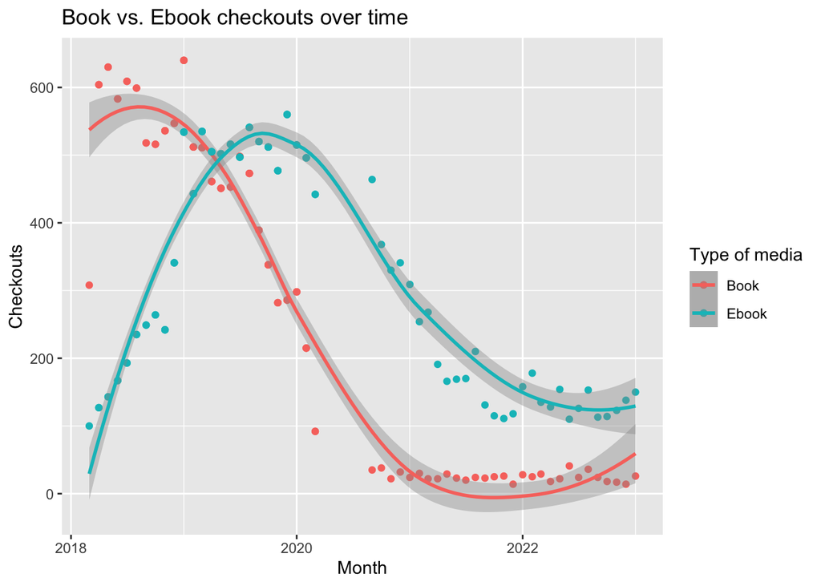

### Second Trends Over Time Chart

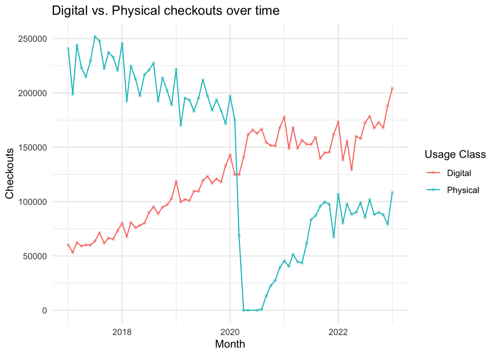

### My Choice

This bar chart shows the number of print book checkouts over the past 5 years. Similar to the last 2 charts, we can see a large decline in print checkouts in the year 2020. There is also a steady rise from that time, which implies a society that is visiting the library again. I thought it would be important to show, through the three charts, how COVID-19 impacted checkout numbers, evident through metrics on usage class, print books, and even individual physical and ebooks.

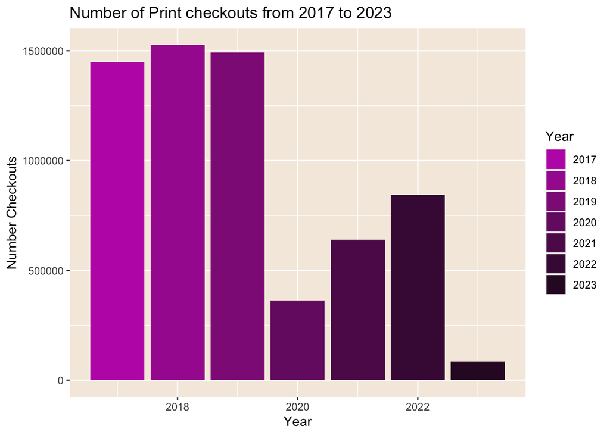